# Causal Inference with IPTW in riskdiff

John D. Murphy

2025-06-25

## Introduction

This vignette demonstrates how to use the **riskdiff** package to perform causal inference using Inverse Probability of Treatment Weighting (IPTW). IPTW is a powerful method for estimating causal effects from observational data by creating a pseudo-population where treatment assignment is independent of measured confounders.

### When to Use IPTW

IPTW is particularly useful when:

- You want to estimate **causal effects** (not just associations)
- You have measured all important confounders
- The treatment assignment mechanism is complex
- You want to estimate population-level effects (ATE) or effects on specific subgroups (ATT/ATC)

### Key Assumptions

IPTW relies on three main assumptions:

1. **No unmeasured confounding**: All confounders are measured and included
2. **Positivity**: All subjects have non-zero probability of receiving either treatment
3. **Correct model specification**: The propensity score model is correctly specified

## Basic IPTW Analysis

Let’s start with a simple example using the Cachar cancer screening dataset:

```r
# Load the data
data(cachar_sample)

# Quick look at the data
head(cachar_sample)
```

```
#>   id age    sex  residence smoking tobacco_chewing areca_nut alcohol
#> 1  1  53 female urban slum      No             Yes       Yes      No
#> 2  2  25   male      rural      No              No       Yes      No
#> 3  3  18 female      rural      No              No       Yes      No
#> 4  4  28 female      rural      No             Yes       Yes      No
#> 5  5  51   male      rural      No             Yes        No      No
#> 6  6  25 female      rural      No              No        No      No
#>   abnormal_screen head_neck_abnormal age_group tobacco_areca_both
#> 1               0                  0     40-60                Yes
#> 2               0                  0  Under 40                 No
#> 3               0                  0  Under 40                 No
#> 4               0                  0  Under 40                Yes
#> 5               0                  0     40-60                 No
#> 6               0                  0  Under 40                 No
```

```r
table(cachar_sample$areca_nut, cachar_sample$abnormal_screen)
```

```
#>
#>          0    1
#>   No   751   27
#>   Yes 1348  374
```

### Step 1: Calculate IPTW Weights

First, we estimate propensity scores and calculate weights:

```r
# Calculate ATE weights for areca nut use
iptw_result <- calc_iptw_weights(
  data = cachar_sample,
  treatment = "areca_nut",
  covariates = c("age", "sex", "residence", "smoking", "tobacco_chewing"),
  weight_type = "ATE",
  verbose = TRUE
)
```

```
#> Fitting propensity score model using logistic regression
#> Sample size: 2500
#> Treatment prevalence: 0.689
#> Trimmed 20 weights below 0.428 and 25 weights above 4.075
#> Weight summary:
#>    Min. 1st Qu.  Median    Mean 3rd Qu.    Max.
#>  0.4277  0.7291  0.7957  0.9874  1.0941  4.0753
#>
#> Effective sample size: 1886.4
#> Maximum standardized difference: 0.057
```

```r
# Examine the results
print(iptw_result)
```

```
#> Inverse Probability of Treatment Weighting Results
#> =================================================
#>
#> Propensity Score Model: logistic regression
#> Weight Type: ATE
#> Sample Size: 2500
#> Effective Sample Size: 1886.4
#>
#> Weight Summary:
#>    Min. 1st Qu.  Median    Mean 3rd Qu.    Max.
#>  0.4277  0.7291  0.7957  0.9874  1.0941  4.0753
#>
#> Covariate Balance:
#>         variable std_diff_unweighted std_diff_weighted
#>              age          0.55269148      -0.007137053
#>              sex          0.21677976       0.049132648
#>        residence         -0.02416585      -0.018322013
#>          smoking         -0.09149158      -0.050166259
#>  tobacco_chewing          1.02667004       0.057051627
```

### Step 2: Check IPTW Assumptions

Before interpreting results, we should check key assumptions:

```r
# Comprehensive assumption checking
assumptions <- check_iptw_assumptions(iptw_result, verbose = TRUE)
```

```
#> IPTW Assumptions Check
#> ======================
#>
#> Overall Assessment: ✓ PASS
#>
#> 1. Positivity (Non-zero probability of treatment)
#>    Propensity score range: [0.258, 0.976]
#>    Extreme values (PS < 0.05): 0
#>    Extreme values (PS > 0.95): 84
#>    Status: ✓ OK
#>
#> 2. Covariate Balance
#>    Maximum standardized difference: 0.057
#>    Status: ✓ BALANCED
#>
#> 3. Weight Distribution
#>    Weight range: [0.43, 4.08]
#>    Effective sample size ratio: 0.755
#>    Status: ✓ OK
```

### Step 3: Visualize Balance

Visual diagnostics help assess whether weighting achieved balance:

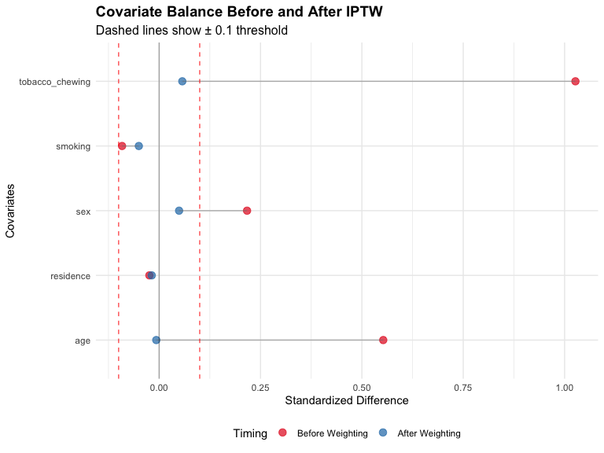

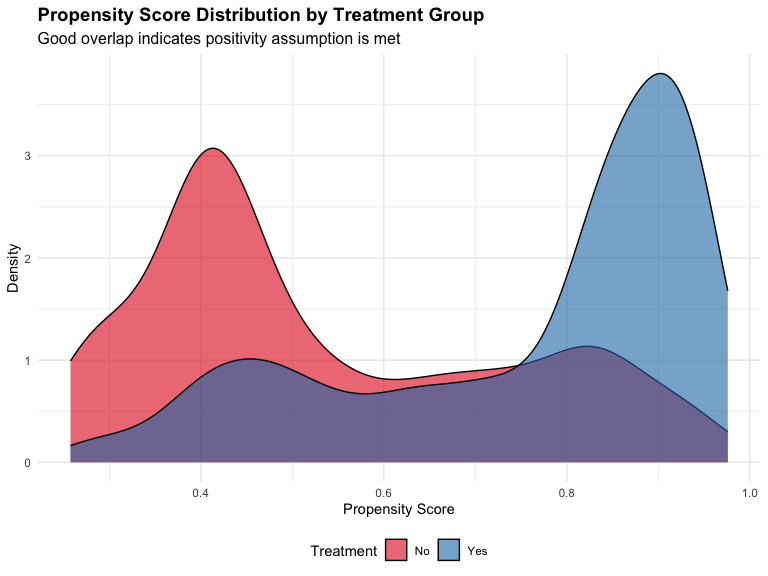

```r
# Create balance plots (requires ggplot2)
if (requireNamespace("ggplot2", quietly = TRUE)) {
  plots <- create_balance_plots(iptw_result, plot_type = "both")
  print(plots$love_plot)
  print(plots$ps_plot)
}
```

### Step 4: Estimate Causal Risk Difference

Now we can estimate the causal effect:

```r
# Estimate ATE using IPTW
rd_causal <- calc_risk_diff_iptw(
  data = cachar_sample,
  outcome = "abnormal_screen",
  treatment = "areca_nut",
  covariates = c("age", "sex", "residence", "smoking", "tobacco_chewing"),
  weight_type = "ATE",
  verbose = TRUE
)
```

[output not shown]

```r
print(rd_causal)
```

```
#> IPTW-Standardized Risk Difference Results
#> =========================================
#>
#> Treatment: areca_nut
#> Weight Type: ATE
#> Effective Sample Size: 1886.4
#>
#> Risk in Treated: 19.3%
#> Risk in Control: 4.1%
#> Risk Difference: 15.23%
#> 95%CI: (12.44%, 18.01%)
#> P-value: <0.001
```

```r
summary(rd_causal)
```

```
#> IPTW Risk Difference Analysis Summary
#> ====================================
#>
#> Treatment Variable: areca_nut
#> Weight Type: ATE weights
#> Effective Sample Size: 1886.4
#>
#> Effect Estimates:
#> -----------------
#> Risk in Treated Group: 19.3%
#> Risk in Control Group: 4.1%
#> Risk Difference: 15.23%
#> 95%Confidence Interval: (12.44%, 18.01%)
#> P-value: <0.001
#> Result: Statistically significant at α = 0.05
#>
#> Interpretation:
#> ---------------
#> The ATE shows a large increased risk of 15.2 percentage points.
#>
#> Note: Statistical significance does not necessarily imply clinical
#> significance. Consider the magnitude of effect in context.
```

## Different Types of Causal Effects

IPTW can estimate different causal estimands depending on the research question:

### Average Treatment Effect (ATE)

The effect of treatment if the entire population received treatment vs. if none received treatment:

```r
rd_ate <- calc_risk_diff_iptw(
  data = cachar_sample,
  outcome = "abnormal_screen",
  treatment = "areca_nut",
  covariates = c("age", "sex", "residence", "smoking"),
  weight_type = "ATE"
)

cat("ATE: The average causal effect of areca nut use in the population\n")
```

```
#> ATE: The average causal effect of areca nut use in the population
```

```r
cat("Risk Difference:", scales::percent(rd_ate$rd_iptw, accuracy = 0.01), "\n")
```

```
#> Risk Difference: 17.21%
```

### Average Treatment Effect on the Treated (ATT)

The effect among those who actually received treatment:

```r
rd_att <- calc_risk_diff_iptw(
  data = cachar_sample,
  outcome = "abnormal_screen",
  treatment = "areca_nut",
  covariates = c("age", "sex", "residence", "smoking"),
  weight_type = "ATT"
)

cat("ATT: The average causal effect among areca nut users\n")
```

```
#> ATT: The average causal effect among areca nut users
```

```r
cat("Risk Difference:", scales::percent(rd_att$rd_iptw, accuracy = 0.01), "\n")
```

```
#> Risk Difference: 18.29%
```

### Average Treatment Effect on the Controls (ATC)

The effect among those who did not receive treatment:

```r
rd_atc <- calc_risk_diff_iptw(
  data = cachar_sample,
  outcome = "abnormal_screen",
  treatment = "areca_nut",
  covariates = c("age", "sex", "residence", "smoking"),
  weight_type = "ATC"
)

cat("ATC: The average causal effect among non-users of areca nut\n")
```

```
#> ATC: The average causal effect among non-users of areca nut
```

```r
cat("Risk Difference:", scales::percent(rd_atc$rd_iptw, accuracy = 0.01), "\n")
```

```
#> Risk Difference: 14.78%
```

## Advanced Options

### Bootstrap Confidence Intervals

For small samples or when assumptions are questionable, bootstrap confidence intervals may be more robust:

```r
rd_bootstrap <- calc_risk_diff_iptw(
  data = cachar_sample,
  outcome = "head_neck_abnormal",
  treatment = "tobacco_chewing",
  covariates = c("age", "sex", "residence", "areca_nut"),
  bootstrap_ci = TRUE,
  boot_n = 500,  # Use more in practice (1000+)
  verbose = FALSE
)

print(rd_bootstrap)
```

```
#> IPTW-Standardized Risk Difference Results
#> =========================================
#>
#> Treatment: tobacco_chewing
#> Weight Type: ATE
#> Effective Sample Size: 1982.5
#>
#> Risk in Treated: 23.0%
#> Risk in Control: 11.8%
#> Risk Difference: 11.17%
#> 95%CI: (8.23%, 14.22%)
#> P-value: <0.001
#>
#> Note: Confidence intervals based on 500 bootstrap replicates
```

### Different Propensity Score Models

You can specify different link functions for the propensity score model:

```r
# Logistic regression (default)
ps_logit <- calc_iptw_weights(
  data = cachar_sample,
  treatment = "tobacco_chewing",
  covariates = c("age", "sex", "residence", "areca_nut"),
  method = "logistic"
)

# Probit regression
ps_probit <- calc_iptw_weights(
  data = cachar_sample,
  treatment = "tobacco_chewing",
  covariates = c("age", "sex", "residence", "areca_nut"),
  method = "probit"
)

# Compare propensity score distributions
cat("Logistic PS range:", round(range(ps_logit$ps), 3), "\n")
```

```
#> Logistic PS range: 0.155 0.783
```

```r
cat("Probit PS range:", round(range(ps_probit$ps), 3), "\n")
```

```
#> Probit PS range: 0.152 0.783
```

### Weight Stabilization and Trimming

Stabilized weights often have better properties:

```r
# Unstabilized weights
ps_unstab <- calc_iptw_weights(
  data = cachar_sample,
  treatment = "areca_nut",
  covariates = c("age", "sex", "residence"),
  stabilize = FALSE
)

# Stabilized weights (default)
ps_stab <- calc_iptw_weights(
  data = cachar_sample,
  treatment = "areca_nut",
  covariates = c("age", "sex", "residence"),
  stabilize = TRUE
)

cat("Unstabilized weight variance:", round(var(ps_unstab$weights), 2), "\n")
```

```
#> Unstabilized weight variance: 1.64
```

```r
cat("Stabilized weight variance:", round(var(ps_stab$weights), 2), "\n")
```

```
#> Stabilized weight variance: 0.11
```

Extreme weights can be problematic and may need trimming:

```r
# Check for extreme weights
summary(ps_stab$weights)
```

```
#>    Min. 1st Qu.  Median    Mean 3rd Qu.    Max.
#>  0.5573  0.8052  0.9171  1.0007  1.1053  2.6419
```

```r
# Trim at 1st and 99th percentiles
ps_trimmed <- calc_iptw_weights(
  data = cachar_sample,
  treatment = "areca_nut",
  covariates = c("age", "sex", "residence"),
  trim_weights = TRUE,
  trim_quantiles = c(0.01, 0.99)
)

cat("Original weight range:", round(range(ps_stab$weights), 2), "\n")
```

```
#> Original weight range: 0.56 2.64
```

```r
cat("Trimmed weight range:", round(range(ps_trimmed$weights), 2), "\n")
```

```
#> Trimmed weight range: 0.56 2.64
```

[output not shown]

## Troubleshooting Common Issues

### Poor Balance

If covariates remain imbalanced after weighting:

```r
# Check which variables have poor balance
assumptions <- check_iptw_assumptions(iptw_result)
poor_balance_vars <- assumptions$balance$poor_balance_vars

if (length(poor_balance_vars) > 0) {
  cat("Variables with poor balance:", paste(poor_balance_vars, collapse = ", "), "\n")

  # Try including interactions or polynomial terms
  iptw_improved <- calc_iptw_weights(
    data = cachar_sample,
    treatment = "areca_nut",
    covariates = c("age", "I(age^2)", "sex", "residence",
                   "smoking", "age:sex"),  # Add interactions
    weight_type = "ATE"
  )
}
```

### Extreme Propensity Scores

When subjects have very high or low propensity scores:

```r
# Check propensity score distribution
iptw_result <- calc_iptw_weights(
  data = cachar_sample,
  treatment = "areca_nut",
  covariates = c("age", "sex", "residence")
)

# Identify subjects with extreme scores
extreme_low <- which(iptw_result$ps < 0.05)
extreme_high <- which(iptw_result$ps > 0.95)

if (length(extreme_low) > 0 || length(extreme_high) > 0) {
  cat("Consider trimming sample to region of common support\n")

  # Restrict to common support
  common_support <- iptw_result$ps >= 0.05 & iptw_result$ps <= 0.95
  data_restricted <- cachar_sample[common_support, ]

  # Re-analyze with restricted sample
  rd_restricted <- calc_risk_diff_iptw(
    data = data_restricted,
    outcome = "abnormal_screen",
    treatment = "areca_nut",
    covariates = c("age", "sex", "residence")
  )
}
```

### Model Specification

Testing different model specifications:

```r
# Simple model
ps_simple <- calc_iptw_weights(
  data = cachar_sample,
  treatment = "areca_nut",
  covariates = c("age", "sex")
)

# Complex model with interactions
ps_complex <- calc_iptw_weights(
  data = cachar_sample,
  treatment = "areca_nut",
  covariates = c("age", "I(age^2)", "sex", "residence",
                 "smoking", "tobacco_chewing", "age:sex")
)

# Compare balance
check_iptw_assumptions(ps_simple, verbose = FALSE)
check_iptw_assumptions(ps_complex, verbose = FALSE)
```

## Sensitivity Analysis

IPTW assumes no unmeasured confounding. Sensitivity analysis can assess robustness:

```r
# Simulate an unmeasured confounder
set.seed(123)
cachar_sample$unmeasured_confounder <- rbinom(nrow(cachar_sample), 1, 0.3)

# Compare results with and without the unmeasured confounder
rd_without_u <- calc_risk_diff_iptw(
  data = cachar_sample,
  outcome = "abnormal_screen",
  treatment = "areca_nut",
  covariates = c("age", "sex", "residence")
)

rd_with_u <- calc_risk_diff_iptw(
  data = cachar_sample,
  outcome = "abnormal_screen",
  treatment = "areca_nut",
  covariates = c("age", "sex", "residence", "unmeasured_confounder")
)

cat("Without unmeasured confounder:", scales::percent(rd_without_u$rd_iptw), "\n")
cat("With unmeasured confounder:", scales::percent(rd_with_u$rd_iptw), "\n")
cat("Difference:", scales::percent(abs(rd_without_u$rd_iptw - rd_with_u$rd_iptw)), "\n")
```

## Best Practices

1. **Always check assumptions** before interpreting results
2. **Visualize balance** using love plots and propensity score distributions
3. **Consider the estimand** (ATE vs. ATT vs. ATC) based on your research question
4. **Use stabilized weights** unless you have a specific reason not to
5. **Trim extreme weights** cautiously - they may indicate model misspecification
6. **Compare with regression adjustment** as a sensitivity check
7. **Report effective sample size** to assess precision loss
8. **Consider bootstrap CIs** for small samples or non-normal distributions

## Reporting IPTW Results

When reporting IPTW analyses, include:

1. **Propensity score model specification** and diagnostics
2. **Balance assessment** before and after weighting
3. **Weight distribution** and any trimming performed
4. **Effective sample size** and precision considerations
5. **Sensitivity analyses** when possible
6. **Clear statement of estimand** (ATE/ATT/ATC)

## Conclusion

IPTW provides a powerful framework for causal inference from observational data. The **riskdiff** package makes these methods accessible while providing essential diagnostics and visualizations. Remember that causal inference requires careful thought about study design, confounders, and assumptions - the methods are only as good as these foundational elements.

For more advanced applications, consider methods like: - Marginal structural models for time-varying treatments - Doubly robust estimation combining IPTW with outcome modeling - Machine learning approaches for propensity score estimation

## References

Austin, P. C. (2011). An introduction to propensity score methods for reducing the effects of confounding in observational studies. *Multivariate Behavioral Research*, 46(3), 399-424.

Hernán, M. A., & Robins, J. M. (2020). *Causal inference: What if*. Boca Raton: Chapman & Hall/CRC.

Robins, J. M., Hernán, M. A., & Brumback, B. (2000). Marginal structural models and causal inference in epidemiology. *Epidemiology*, 11(5), 550-560.